# Hierarchal Clustering

```r
source('Visualisation/my_functions.R')
```

# Libraries

```r
library(reshape2)
library(ggdendro)
library(ggplot2)
library(cowplot)
library(dplyr)
library(RColorBrewer)
library(scico)
library(ggpubr)
```

# Load distance matrices

Distance matrices

```r
# entire population
CTAS_pillar2 = read.csv('Data/TTI_Pillar2/DistanceMatrixJaccardOriginPillar2.csv')
CTAS_sgss = read.csv('Data/TTI_SGSS/DistanceMatrixJaccardOriginSGSS.csv')
ONS = read.csv('Data/CommunityInfectionSurvey/DistanceMatrixJaccard.csv')
CSS = read.csv('Data/CovidSymptomStudy/JaccardSymptomWide.csv')

# age stratified
Zoe_children = read.csv('Data/CovidSymptomStudyAgeSeperated/JaccardSymptom_children.csv')
Zoe_adults = read.csv('Data/CovidSymptomStudyAgeSeperated/JaccardSymptom_adults.csv')
Zoe_elder = read.csv('Data/CovidSymptomStudyAgeSeperated/JaccardSymptom_elder.csv')

ONS_children = read.csv('Data/CommunityInfectionSurveyAgeStratified/DistanceMatrixJaccard_18.csv')
ONS_adults = read.csv('Data/CommunityInfectionSurveyAgeStratified/DistanceMatrixJaccard_18_54.csv')
ONS_elder = read.csv('Data/CommunityInfectionSurveyAgeStratified/DistanceMatrixJaccard_55.csv')

CTAS_p2_children = read.csv('Data/TTI_Pillar2_AgeStratified/JaccardDistanceMatrixPopulationStatsOriginP2Below18.csv')
CTAS_p2_adults = read.csv('Data/TTI_Pillar2_AgeStratified/JaccardDistanceMatrixPopulationStatsOriginP218-54.csv')
CTAS_p2_elder = read.csv('Data/TTI_Pillar2_AgeStratified/JaccardDistanceMatrixPopulationStatsOriginP255Plus.csv')

CTAS_SGSS_children = read.csv('Data/TTI_SGSS_AgeStratified/JaccardDistanceMatrixPopulationStatsOriginSGSSBelow18.csv')
CTAS_SGSS_adults = read.csv('Data/TTI_SGSS_AgeStratified/JaccardDistanceMatrixPopulationStatsOriginSGSS18-54.csv')
CTAS_SGSS_elder = read.csv('Data/TTI_SGSS_AgeStratified/JaccardDistanceMatrixPopulationStatsOriginSGSS55Plus.csv')
```

Lookups

```r
SymptomsNameCategoryLookup= read.csv(
  'Data/Lookups/SymptomNameCategoryLookup.csv'
  )
categories = read.csv(
  'Data/Lookups/CategoriesLookup.csv'
  )
```

Convert to long data format, which is required for the heatmaps, then join both columns to the lookup table to get formatted names. Filter down to the lookup entries for the relevant dataset only.

```r
CTAS_pillar2_long = melt(CTAS_pillar2) %>%
  inner_join(SymptomsNameCategoryLookup, by = c('X' = 'symptom_name_raw')) %>%
  filter(dataset == 'CTAS') %>%
  inner_join(SymptomsNameCategoryLookup, by = c('variable' = 'symptom_name_raw')) %>%
  filter(dataset.x == 'CTAS') %>%
  filter(dataset.y == 'CTAS') %>%
  select(
    symptom_name_formatted.x,
    symptom_name_formatted.y,
    value
  )
CTAS_sgss_long = melt(CTAS_sgss) %>%
  inner_join(SymptomsNameCategoryLookup, by = c('X' = 'symptom_name_raw')) %>%
  filter(dataset == 'CTAS') %>%
  inner_join(SymptomsNameCategoryLookup, by = c('variable' = 'symptom_name_raw')) %>%
  filter(dataset.x == 'CTAS') %>%
  filter(dataset.y == 'CTAS') %>%
  select(
    symptom_name_formatted.x,
    symptom_name_formatted.y,
    value
  )
ONS_long = melt(ONS) %>%
  inner_join(SymptomsNameCategoryLookup, by = c('X' = 'symptom_name_raw')) %>%
  filter(dataset == 'ONS') %>%
  inner_join(SymptomsNameCategoryLookup, by = c('variable' = 'symptom_name_raw')) %>%
  filter(dataset.x == 'ONS') %>%
  filter(dataset.y == 'ONS') %>%
  select(
    symptom_name_formatted.x,
    symptom_name_formatted.y,
    value
  )
CSS_long = melt(CSS) %>%
  inner_join(SymptomsNameCategoryLookup, by = c('X' = 'symptom_name_raw')) %>%
  filter(dataset == 'Zoe') %>%
  inner_join(SymptomsNameCategoryLookup, by = c('variable' = 'symptom_name_raw')) %>%
  filter(dataset.x == 'Zoe') %>%
  filter(dataset.y == 'Zoe') %>%
  select(
    symptom_name_formatted.x,
    symptom_name_formatted.y,
    value
  )
# age stratified
# zoe
Zoe_long_children = melt(Zoe_children) %>%
  inner_join(SymptomsNameCategoryLookup, by = c('X' = 'symptom_name_raw')) %>%
  filter(dataset == 'Zoe') %>%
  inner_join(SymptomsNameCategoryLookup, by = c('variable' = 'symptom_name_raw')) %>%
  filter(dataset.x == 'Zoe') %>%
  filter(dataset.y == 'Zoe') %>%
  select(
    symptom_name_formatted.x,
    symptom_name_formatted.y,
    value
  )
Zoe_long_adults = melt(Zoe_adults) %>%
  inner_join(SymptomsNameCategoryLookup, by = c('X' = 'symptom_name_raw')) %>%
  filter(dataset == 'Zoe') %>%
  inner_join(SymptomsNameCategoryLookup, by = c('variable' = 'symptom_name_raw')) %>%
  filter(dataset.x == 'Zoe') %>%
  filter(dataset.y == 'Zoe') %>%
  select(
    symptom_name_formatted.x,
    symptom_name_formatted.y,
    value
  )
Zoe_long_elder = melt(Zoe_elder) %>%
  inner_join(SymptomsNameCategoryLookup, by = c('X' = 'symptom_name_raw')) %>%
  filter(dataset == 'Zoe') %>%
  inner_join(SymptomsNameCategoryLookup, by = c('variable' = 'symptom_name_raw')) %>%
  filter(dataset.x == 'Zoe') %>%
  filter(dataset.y == 'Zoe') %>%
  select(
    symptom_name_formatted.x,
    symptom_name_formatted.y,
    value
  )
# pillar 2
CTAS_p2_children_long = melt(CTAS_p2_children) %>%
  inner_join(SymptomsNameCategoryLookup, by = c('X' = 'symptom_name_raw')) %>%
  filter(dataset == 'CTAS') %>%
  inner_join(SymptomsNameCategoryLookup, by = c('variable' = 'symptom_name_raw')) %>%
  filter(dataset.x == 'CTAS') %>%
  filter(dataset.y == 'CTAS') %>%
  select(
    symptom_name_formatted.x,
    symptom_name_formatted.y,
    value
  )
CTAS_p2_adults_long = melt(CTAS_p2_adults) %>%
  inner_join(SymptomsNameCategoryLookup, by = c('X' = 'symptom_name_raw')) %>%
  filter(dataset == 'CTAS') %>%
  inner_join(SymptomsNameCategoryLookup, by = c('variable' = 'symptom_name_raw')) %>%
  filter(dataset.x == 'CTAS') %>%
  filter(dataset.y == 'CTAS') %>%
  select(
    symptom_name_formatted.x,
    symptom_name_formatted.y,
    value
  )
CTAS_p2_elder_long = melt(CTAS_p2_elder) %>%
  inner_join(SymptomsNameCategoryLookup, by = c('X' = 'symptom_name_raw')) %>%
  filter(dataset == 'CTAS') %>%
  inner_join(SymptomsNameCategoryLookup, by = c('variable' = 'symptom_name_raw')) %>%
  filter(dataset.x == 'CTAS') %>%
  filter(dataset.y == 'CTAS') %>%
  select(
    symptom_name_formatted.x,
    symptom_name_formatted.y,
    value
  )
# sgss
CTAS_SGSS_children_long = melt(CTAS_SGSS_children) %>%
  inner_join(SymptomsNameCategoryLookup, by = c('X' = 'symptom_name_raw')) %>%
  filter(dataset == 'CTAS') %>%
  inner_join(SymptomsNameCategoryLookup, by = c('variable' = 'symptom_name_raw')) %>%
  filter(dataset.x == 'CTAS') %>%
  filter(dataset.y == 'CTAS') %>%
  select(
    symptom_name_formatted.x,
    symptom_name_formatted.y,
    value
  )
CTAS_SGSS_adults_long = melt(CTAS_SGSS_adults) %>%
  inner_join(SymptomsNameCategoryLookup, by = c('X' = 'symptom_name_raw')) %>%
  filter(dataset == 'CTAS') %>%
  inner_join(SymptomsNameCategoryLookup, by = c('variable' = 'symptom_name_raw')) %>%
  filter(dataset.x == 'CTAS') %>%
  filter(dataset.y == 'CTAS') %>%
  select(
    symptom_name_formatted.x,
    symptom_name_formatted.y,
    value
  )
CTAS_SGSS_elder_long = melt(CTAS_SGSS_elder) %>%
  inner_join(SymptomsNameCategoryLookup, by = c('X' = 'symptom_name_raw')) %>%
  filter(dataset == 'CTAS') %>%
  inner_join(SymptomsNameCategoryLookup, by = c('variable' = 'symptom_name_raw')) %>%
  filter(dataset.x == 'CTAS') %>%
  filter(dataset.y == 'CTAS') %>%
  select(
    symptom_name_formatted.x,
    symptom_name_formatted.y,
    value
  )
# ons
ONS_children_long = melt(ONS_children) %>%
  inner_join(SymptomsNameCategoryLookup, by = c('X' = 'symptom_name_raw')) %>%
  filter(dataset == 'ONS') %>%
  inner_join(SymptomsNameCategoryLookup, by = c('variable' = 'symptom_name_raw')) %>%
  filter(dataset.x == 'ONS') %>%
  filter(dataset.y == 'ONS') %>%
  select(
    symptom_name_formatted.x,
    symptom_name_formatted.y,
    value
  )
ONS_adults_long = melt(ONS_adults) %>%
  inner_join(SymptomsNameCategoryLookup, by = c('X' = 'symptom_name_raw')) %>%
  filter(dataset == 'ONS') %>%
  inner_join(SymptomsNameCategoryLookup, by = c('variable' = 'symptom_name_raw')) %>%
  filter(dataset.x == 'ONS') %>%
  filter(dataset.y == 'ONS') %>%
  select(
    symptom_name_formatted.x,
    symptom_name_formatted.y,
    value
  )
ONS_elder_long = melt(ONS_elder) %>%
  inner_join(SymptomsNameCategoryLookup, by = c('X' = 'symptom_name_raw')) %>%
  filter(dataset == 'ONS') %>%
  inner_join(SymptomsNameCategoryLookup, by = c('variable' = 'symptom_name_raw')) %>%
  filter(dataset.x == 'ONS') %>%
  filter(dataset.y == 'ONS') %>%
  select(
    symptom_name_formatted.x,
    symptom_name_formatted.y,
    value
  )
```

Symptom information tables

```r
# entire population
CTAS_pillar2_symptom_info = read.csv('Data/TTI_SGSS/Symptom_infoOriginSGSS.csv')
CTAS_sgss_symptom_info = read.csv('Data/TTI_Pillar2/Symptom_infoOriginP2.csv')
ONS_symptom_info = read.csv('Data/CommunityInfectionSurvey/symptoms_info.csv')
CSS_symptom_info = read.csv('Data/CovidSymptomStudy/DemographicSymptom_wide.csv')

# age stratified
zoe_symptom_info_children = read.csv('Data/CovidSymptomStudyAgeSeperated/DemographicSymptom_children.csv')
zoe_symptom_info_adults = read.csv('Data/CovidSymptomStudyAgeSeperated/DemographicSymptom_adults.csv')
zoe_symptom_info_elder = read.csv('Data/CovidSymptomStudyAgeSeperated/DemographicSymptom_elder.csv')

CTAS_p2_symptom_info_children = read.csv('Data/TTI_Pillar2_AgeStratified/Symptom_infoOriginP2Below18.csv')
CTAS_p2_symptom_info_adults = read.csv('Data/TTI_Pillar2_AgeStratified/Symptom_infoOriginP218-54.csv')
CTAS_p2_symptom_info_elder = read.csv('Data/TTI_Pillar2_AgeStratified/Symptom_infoOriginP255Plus.csv')

CTAS_SGSS_symptom_info_children = read.csv('Data/TTI_SGSS_AgeStratified/Symptom_infoOriginSGSSBelow18.csv')
CTAS_SGSS_symptom_info_adults = read.csv('Data/TTI_SGSS_AgeStratified/Symptom_infoOriginSGSS18-54.csv')
CTAS_SGSS_symptom_info_elder = read.csv('Data/TTI_SGSS_AgeStratified/Symptom_infoOriginSGSS55Plus.csv')

ONS_symptom_info_children = read.csv('Data/CommunityInfectionSurveyAgeStratified/symptoms_info_18.csv')
ONS_symptom_info_adults = read.csv('Data/CommunityInfectionSurveyAgeStratified/symptoms_info_18_54.csv')
ONS_symptom_info_elder = read.csv('Data/CommunityInfectionSurveyAgeStratified/symptoms_info_55.csv')
```

Establish uniform naming convention

```r
# entire population
colnames(CTAS_pillar2_symptom_info)[1] = 'symptom_name_raw'
colnames(CTAS_sgss_symptom_info)[1] = 'symptom_name_raw'
colnames(ONS_symptom_info)[2] = 'symptom_name_raw'
colnames(CSS_symptom_info)[2] = 'symptom_name_raw'

# age stratified

colnames(zoe_symptom_info_children)[2] = 'symptom_name_raw'
colnames(zoe_symptom_info_adults)[2] = 'symptom_name_raw'
colnames(zoe_symptom_info_elder)[2] = 'symptom_name_raw'

colnames(CTAS_p2_symptom_info_children)[1] = 'symptom_name_raw'
colnames(CTAS_p2_symptom_info_adults)[1] = 'symptom_name_raw'
colnames(CTAS_p2_symptom_info_elder)[1] = 'symptom_name_raw'

colnames(CTAS_SGSS_symptom_info_children)[1] = 'symptom_name_raw'
colnames(CTAS_SGSS_symptom_info_adults)[1] = 'symptom_name_raw'
colnames(CTAS_SGSS_symptom_info_elder)[1] = 'symptom_name_raw'

colnames(ONS_symptom_info_children)[2] = 'symptom_name_raw'
colnames(ONS_symptom_info_adults)[2] = 'symptom_name_raw'
colnames(ONS_symptom_info_elder)[2] = 'symptom_name_raw'
```

## Dendrogram grobs

```r
category_legend = guides(colour = guide_legend(override.aes = list(size=5), nrow = 3))

y_scale = scale_y_continuous(
    name="Jaccard distance",
    breaks = c(0, 0.2, 0.4, 0.6, 0.8, 1.0),
    limits=c(-0.5, 1))

remove_axis_arrange_legend = theme(axis.title.x=element_blank(),
        axis.text.x=element_blank(),
        axis.ticks.x=element_blank(),
        axis.line = element_blank(),
        axis.title.y=element_blank(),
        axis.text.y=element_blank(),
        axis.ticks.y=element_blank(),
        legend.position = "bottom",
        legend.box = "vertical",
        legend.justification = ("right")
  )

size_scaling =  scale_size_continuous(
    breaks = c(20, 40, 60, 80, 100),
    labels = c(20, 40, 60, 80, 100),
    limits = c(0, 100),
    range = c(2,6)
   )

shifted_y_scale = scale_y_continuous(
    name="Jaccard distance",
    breaks = c(0, 0.2, 0.4, 0.6, 0.8, 1.0),
    limits=c(-0.5, 1))
```

Heatmap grobs

```r
heatmap_theme = theme(axis.text.y = element_blank(),
        axis.title.y = element_blank(),
        axis.ticks.y = element_blank(),
        legend.position = 'top',
        axis.text.x = element_text(
          angle = 90,
          hjust = 1,
          vjust = 0.5,
          size = 12))


z_axis_scale = scico::scale_fill_scico(
    palette = "roma",
    limits = c(0, 1))
```

# Data cleaning

We wrangle the raw distance matrices into a form that can be used as an input to as.dist. Really ought to convert this into a function…

```r
# pillar 2
CTAS_pillar2_symptom_names = CTAS_pillar2[,1]
CTAS_pillar2 = CTAS_pillar2[-1]
rownames(CTAS_pillar2) <- CTAS_pillar2_symptom_names
CTAS_pillar2_dist = as.dist(CTAS_pillar2)

# sgss
CTAS_sgss_symptom_names = CTAS_sgss[,1]
CTAS_sgss = CTAS_sgss[-1]
rownames(CTAS_sgss) <- CTAS_sgss_symptom_names
CTAS_sgss_dist = as.dist(CTAS_sgss)

# ONS
ONS_symptom_names = ONS[,1]
ONS = ONS[,-1]
rownames(ONS) <- ONS_symptom_names
ONS_dist = as.dist(ONS)

# CSS
CSS_symptom_names = CSS[,1]
CSS = CSS[,-1]
rownames(CSS) <- CSS_symptom_names
CSS_dist = as.dist(CSS)

# age stratified
zoe_symptom_names_children = Zoe_children[,1]
Zoe_children = Zoe_children[-1]
rownames(Zoe_children) <- zoe_symptom_names_children
zoe_dist_children = as.dist(Zoe_children)

zoe_symptom_names_adults = Zoe_adults[,1]
Zoe_adults = Zoe_adults[-1]
rownames(Zoe_adults) <- zoe_symptom_names_adults
zoe_dist_adults = as.dist(Zoe_adults)

zoe_symptom_names_elder = Zoe_elder[,1]
Zoe_elder = Zoe_elder[-1]
rownames(Zoe_elder) <- zoe_symptom_names_elder
zoe_dist_elder = as.dist(Zoe_elder)

# CTAS pillar 2
p2_symptom_names_children = CTAS_p2_children[,1]
CTAS_p2_children = CTAS_p2_children[-1]
rownames(CTAS_p2_children) <- p2_symptom_names_children
p2_dist_children = as.dist(CTAS_p2_children)

p2_symptom_names_adults = CTAS_p2_adults[,1]
CTAS_p2_adults = CTAS_p2_adults[-1]
rownames(CTAS_p2_adults) <- p2_symptom_names_adults
p2_dist_adults = as.dist(CTAS_p2_adults)

p2_symptom_names_elder = CTAS_p2_elder[,1]
CTAS_p2_elder = CTAS_p2_elder[-1]
rownames(CTAS_p2_elder) <- p2_symptom_names_elder
p2_dist_elder = as.dist(CTAS_p2_elder)


# CTAS SGSS
SGSS_symptom_names_children = CTAS_SGSS_children[,1]
CTAS_SGSS_children = CTAS_SGSS_children[-1]
rownames(CTAS_SGSS_children) <- SGSS_symptom_names_children
SGSS_dist_children = as.dist(CTAS_SGSS_children)

SGSS_symptom_names_adults = CTAS_SGSS_adults[,1]
CTAS_SGSS_adults = CTAS_SGSS_adults[-1]
rownames(CTAS_SGSS_adults) <- SGSS_symptom_names_adults
SGSS_dist_adults = as.dist(CTAS_SGSS_adults)

SGSS_symptom_names_elder = CTAS_SGSS_elder[,1]
CTAS_SGSS_elder = CTAS_SGSS_elder[-1]
rownames(CTAS_SGSS_elder) <- SGSS_symptom_names_elder
SGSS_dist_elder = as.dist(CTAS_SGSS_elder)

# ONS
ONS_symptom_names_children = ONS_children[,1]
ONS_children = ONS_children[-1]
rownames(ONS_children) <- ONS_symptom_names_children
ONS_dist_children = as.dist(ONS_children)

ONS_symptom_names_adults = ONS_adults[,1]
ONS_adults = ONS_adults[-1]
rownames(ONS_adults) <- ONS_symptom_names_adults
ONS_dist_adults = as.dist(ONS_adults)

ONS_symptom_names_elder = ONS_elder[,1]
ONS_elder = ONS_elder[-1]
rownames(ONS_elder) <- ONS_symptom_names_elder
ONS_dist_elder = as.dist(ONS_elder)
```

# Extract symptom_names from datasets

We join the the lookup table that provides fromatted names for symptoms and assigns categories.

```r
# entire population
CTAS_pillar2_symptom_names_df = data.frame(CTAS_pillar2_symptom_names)
colnames(CTAS_pillar2_symptom_names_df) <- 'symptom_name_raw'

CTAS_sgss_symptom_names_df = data.frame(CTAS_sgss_symptom_names)
colnames(CTAS_sgss_symptom_names_df) <- 'symptom_name_raw'

ONS_symptom_names_df = data.frame(ONS_symptom_names)
colnames(ONS_symptom_names_df) <- 'symptom_name_raw'

CSS_symptom_names_df = data.frame(CSS_symptom_names)
colnames(CSS_symptom_names_df) <- 'symptom_name_raw'

# age stratified
# zoe
zoe_symptom_names_df_children = data.frame(zoe_symptom_names_children)
colnames(zoe_symptom_names_df_children) <- 'symptom_name_raw'

zoe_symptom_names_df_adults = data.frame(zoe_symptom_names_adults)
colnames(zoe_symptom_names_df_adults) <- 'symptom_name_raw'

zoe_symptom_names_df_elder = data.frame(zoe_symptom_names_elder)
colnames(zoe_symptom_names_df_elder) <- 'symptom_name_raw'

# pillar 2
p2_symptom_names_df_children = data.frame(p2_symptom_names_children)
colnames(p2_symptom_names_df_children) <- 'symptom_name_raw'

p2_symptom_names_df_adults = data.frame(p2_symptom_names_adults)
colnames(p2_symptom_names_df_adults) <- 'symptom_name_raw'

p2_symptom_names_df_elder = data.frame(p2_symptom_names_elder)
colnames(p2_symptom_names_df_elder) <- 'symptom_name_raw'

# sgss
SGSS_symptom_names_df_children = data.frame(SGSS_symptom_names_children)
colnames(SGSS_symptom_names_df_children) <- 'symptom_name_raw'

SGSS_symptom_names_df_adults = data.frame(SGSS_symptom_names_adults)
colnames(SGSS_symptom_names_df_adults) <- 'symptom_name_raw'

SGSS_symptom_names_df_elder = data.frame(SGSS_symptom_names_elder)
colnames(SGSS_symptom_names_df_elder) <- 'symptom_name_raw'

# ONS
ONS_symptom_names_df_children = data.frame(ONS_symptom_names_children)
colnames(ONS_symptom_names_df_children) <- 'symptom_name_raw'

ONS_symptom_names_df_adults = data.frame(ONS_symptom_names_adults)
colnames(ONS_symptom_names_df_adults) <- 'symptom_name_raw'

ONS_symptom_names_df_elder = data.frame(ONS_symptom_names_elder)
colnames(ONS_symptom_names_df_elder) <- 'symptom_name_raw'
```

Perform joins and do formatting

```r
CTAS_pillar2_symptom_names_df = CTAS_pillar2_symptom_names_df %>%
  inner_join(SymptomsNameCategoryLookup) %>%
  inner_join(CTAS_pillar2_symptom_info) %>%
  filter(dataset == 'CTAS') %>%
  mutate(
    cases_with_symptom_prop = round(proportion_of_cases_with_symptom*100)) %>%
  mutate(symptom_name_formatted_with_perc = paste(
    symptom_name_formatted,
    " (",
    cases_with_symptom_prop,
    "%)",
    sep = ""
  ))
CTAS_sgss_symptom_names_df = CTAS_sgss_symptom_names_df %>%
  inner_join(SymptomsNameCategoryLookup) %>%
  inner_join(CTAS_sgss_symptom_info) %>%
  filter(dataset == 'CTAS') %>%
  mutate(
    cases_with_symptom_prop = round(proportion_of_cases_with_symptom*100)) %>%
  mutate(symptom_name_formatted_with_perc = paste(
    symptom_name_formatted,
    " (",
    cases_with_symptom_prop,
    "%)",
    sep = ""
  ))
ONS_symptom_names_df = ONS_symptom_names_df %>%
  inner_join(SymptomsNameCategoryLookup) %>%
  inner_join(ONS_symptom_info) %>%
  filter(dataset == 'ONS')%>%
  mutate(
    cases_with_symptom_prop = round(proportion_fromsymptomatics)) %>%
  mutate(symptom_name_formatted_with_perc = paste(
    symptom_name_formatted,
    " (",
    cases_with_symptom_prop,
    "%)",
    sep = ""
  ))
CSS_symptom_names_df = CSS_symptom_names_df %>%
  inner_join(SymptomsNameCategoryLookup) %>%
  inner_join(CSS_symptom_info) %>%
  filter(dataset == 'Zoe')%>%
  mutate(
    cases_with_symptom_prop = round(proportion*100)) %>%
  mutate(symptom_name_formatted_with_perc = paste(
    symptom_name_formatted,
    " (",
    cases_with_symptom_prop,
    "%)",
    sep = ""
  ))
# age stratified
zoe_symptom_names_df_children = zoe_symptom_names_df_children %>%
  left_join(SymptomsNameCategoryLookup) %>%
  left_join(zoe_symptom_info_children) %>%
  filter(dataset == 'Zoe') %>%
    mutate(
    cases_with_symptom_prop = round(proportion*100)) %>%
  mutate(symptom_name_formatted_with_perc = paste(
    symptom_name_formatted,
    " (",
    cases_with_symptom_prop,
    "%)",
    sep = ""
  ))
zoe_symptom_names_df_adults = zoe_symptom_names_df_adults %>%
  left_join(SymptomsNameCategoryLookup) %>%
  left_join(zoe_symptom_info_adults) %>%
  filter(dataset == 'Zoe') %>%
    mutate(
    cases_with_symptom_prop = round(proportion*100)) %>%
  mutate(symptom_name_formatted_with_perc = paste(
    symptom_name_formatted,
    " (",
    cases_with_symptom_prop,
    "%)",
    sep = ""
  ))
zoe_symptom_names_df_elder = zoe_symptom_names_df_elder %>%
  left_join(SymptomsNameCategoryLookup) %>%
  left_join(zoe_symptom_info_elder) %>%
  filter(dataset == 'Zoe') %>%
    mutate(
    cases_with_symptom_prop = round(proportion*100)) %>%
  mutate(symptom_name_formatted_with_perc = paste(
    symptom_name_formatted,
    " (",
    cases_with_symptom_prop,
    "%)",
    sep = ""
  ))
# pillar 2
p2_symptom_names_df_children = p2_symptom_names_df_children %>%
  inner_join(SymptomsNameCategoryLookup) %>%
  inner_join(CTAS_p2_symptom_info_children) %>%
  filter(dataset == 'CTAS') %>%
  mutate(
    cases_with_symptom_prop = round(proportion_of_cases_with_symptom*100)) %>%
  mutate(symptom_name_formatted_with_perc = paste(
    symptom_name_formatted,
    " (",
    cases_with_symptom_prop,
    "%)",
    sep = ""
  ))
p2_symptom_names_df_adults = p2_symptom_names_df_adults %>%
  inner_join(SymptomsNameCategoryLookup) %>%
  inner_join(CTAS_p2_symptom_info_adults) %>%
  filter(dataset == 'CTAS') %>%
  mutate(
    cases_with_symptom_prop = round(proportion_of_cases_with_symptom*100)) %>%
  mutate(symptom_name_formatted_with_perc = paste(
    symptom_name_formatted,
    " (",
    cases_with_symptom_prop,
    "%)",
    sep = ""
  ))
p2_symptom_names_df_elder = p2_symptom_names_df_elder %>%
  inner_join(SymptomsNameCategoryLookup) %>%
  inner_join(CTAS_p2_symptom_info_elder) %>%
  filter(dataset == 'CTAS') %>%
  mutate(
    cases_with_symptom_prop = round(proportion_of_cases_with_symptom*100)) %>%
  mutate(symptom_name_formatted_with_perc = paste(
    symptom_name_formatted,
    " (",
    cases_with_symptom_prop,
    "%)",
    sep = ""
  ))
# sgss
SGSS_symptom_names_df_children = SGSS_symptom_names_df_children %>%
  inner_join(SymptomsNameCategoryLookup) %>%
  inner_join(CTAS_SGSS_symptom_info_children) %>%
  filter(dataset == 'CTAS') %>%
  mutate(
    cases_with_symptom_prop = round(proportion_of_cases_with_symptom*100)) %>%
  mutate(symptom_name_formatted_with_perc = paste(
    symptom_name_formatted,
    " (",
    cases_with_symptom_prop,
    "%)",
    sep = ""
  ))
SGSS_symptom_names_df_adults = SGSS_symptom_names_df_adults %>%
  inner_join(SymptomsNameCategoryLookup) %>%
  inner_join(CTAS_SGSS_symptom_info_adults) %>%
  filter(dataset == 'CTAS') %>%
  mutate(
    cases_with_symptom_prop = round(proportion_of_cases_with_symptom*100)) %>%
  mutate(symptom_name_formatted_with_perc = paste(
    symptom_name_formatted,
    " (",
    cases_with_symptom_prop,
    "%)",
    sep = ""
  ))
SGSS_symptom_names_df_elder = SGSS_symptom_names_df_elder %>%
  inner_join(SymptomsNameCategoryLookup) %>%
  inner_join(CTAS_SGSS_symptom_info_elder) %>%
  filter(dataset == 'CTAS') %>%
  mutate(
    cases_with_symptom_prop = round(proportion_of_cases_with_symptom*100)) %>%
  mutate(symptom_name_formatted_with_perc = paste(
    symptom_name_formatted,
    " (",
    cases_with_symptom_prop,
    "%)",
    sep = ""
  ))
# ONS
ONS_symptom_names_df_children = ONS_symptom_names_df_children %>%
  inner_join(SymptomsNameCategoryLookup) %>%
  inner_join(ONS_symptom_info) %>%
  filter(dataset == 'ONS')%>%
  mutate(
    cases_with_symptom_prop = round(proportion_fromsymptomatics)) %>%
  mutate(symptom_name_formatted_with_perc = paste(
    symptom_name_formatted,
    " (",
    cases_with_symptom_prop,
    "%)",
    sep = ""
  ))
ONS_symptom_names_df_adults = ONS_symptom_names_df_adults %>%
  inner_join(SymptomsNameCategoryLookup) %>%
  inner_join(ONS_symptom_info) %>%
  filter(dataset == 'ONS')%>%
  mutate(
    cases_with_symptom_prop = round(proportion_fromsymptomatics)) %>%
  mutate(symptom_name_formatted_with_perc = paste(
    symptom_name_formatted,
    " (",
    cases_with_symptom_prop,
    "%)",
    sep = ""
  ))
ONS_symptom_names_df_elder = ONS_symptom_names_df_elder %>%
  inner_join(SymptomsNameCategoryLookup) %>%
  inner_join(ONS_symptom_info) %>%
  filter(dataset == 'ONS')%>%
  mutate(
    cases_with_symptom_prop = round(proportion_fromsymptomatics)) %>%
  mutate(symptom_name_formatted_with_perc = paste(
    symptom_name_formatted,
    " (",
    cases_with_symptom_prop,
    "%)",
    sep = ""
  ))
```

# DendroHeatmaps

```r
text_size = 0.01
```

## CTAS Pillar 2

The code here is a bit tricky. To begin, we create a dendrogram using the h_clust function. We then extract the dendrogram as line segments using a combination of as.dendrogram and dendro_data. We do this since it allows much more low level graphical tweaking, and plotting other points on top.

```r
CTAS_pillar2_dendro_dd_row = as.dendrogram(
  hclust(
    CTAS_pillar2_dist,
    method = 'complete'
    )
  )
CTAS_pillar2_dendro_data = dendro_data(CTAS_pillar2_dendro_dd_row)
```

The dendro_data table contains the names that were on the Jaccard distance matrix. We join to the symptom information table so that we can encode more information onto the dendrogram.

```r
CTAS_pillar2_dendro_data$labels = CTAS_pillar2_dendro_data$labels %>%
  left_join(
    CTAS_pillar2_symptom_names_df,
    by = c('label' = 'symptom_name_raw')
    )
```

We now recreate the dendrogram in ggplot2, but we can make use of the additional data that has been added to the dendro_data table.

```r
remove_axis_arrange_legend = theme(
  axis.title.x=element_blank(),
        #axis.text.x=element_blank(),
        #axis.ticks.x=element_blank(),
        axis.line = element_blank(),
        axis.title.y=element_blank(),
        axis.text.y=element_blank(),
        axis.ticks.y=element_blank(),
        legend.position = "bottom",
        legend.box = "vertical",
        legend.justification = c(0.5,0))
```

```r
CTAS_pillar2_dendrogram <- ggplot(segment(CTAS_pillar2_dendro_data)) +
  geom_segment(
    aes(x=x, y=y, xend=xend, yend=yend)) +
  geom_text(
    data=label(CTAS_pillar2_dendro_data),
    aes(
      label=symptom_name_formatted_with_perc,
      x=x,
      y=-0.05,
      angle='0',
      hjust = 1,
      label_size = text_size)) +
  geom_point(
    data = CTAS_pillar2_dendro_data$labels,
    aes(
      x=x,
      y=0,
      size=proportion_of_cases_with_symptom*100,
      color=category)) +
  labs(
    size = 'Cases with symptom (%)',
    color = 'Category') +
  theme_cowplot(font_size = 12) +
  remove_axis_arrange_legend +
  shifted_y_scale +
  colour_scale_all +
  size_scaling +
  coord_flip() +
  category_legend
```

```
Ignoring unknown aesthetics: label_size
```

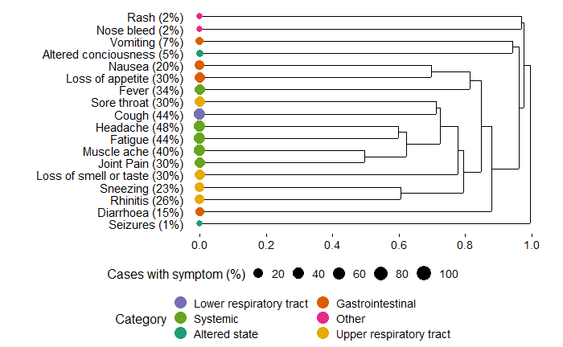

```r
CTAS_pillar2_dendrogram
```

### Heatmap

```r
# get the ordering from the dendrogram
CTAS_pillar2_order = order.dendrogram(CTAS_pillar2_dendro_dd_row)

# Order the levels according to their position in the dendrogram
CTAS_pillar2_long$symptom_name_formatted.x = factor(
  x = CTAS_pillar2_long$symptom_name_formatted.x,
  levels = CTAS_pillar2_long$symptom_name_formatted.x[CTAS_pillar2_order],
  ordered = TRUE
)

CTAS_pillar2_long$symptom_name_formatted.y = factor(
  x = CTAS_pillar2_long$symptom_name_formatted.y,
  levels = CTAS_pillar2_long$symptom_name_formatted.x[rev(CTAS_pillar2_order)],
  ordered = TRUE
)
```

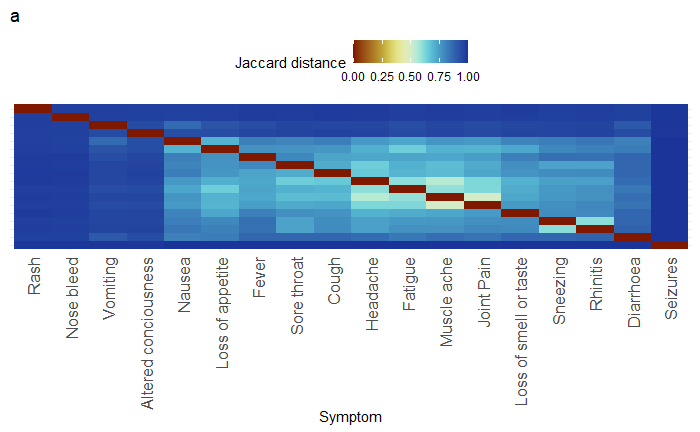

```r
CTAS_pillar2_heatmap <- ggplot(
  data = CTAS_pillar2_long,
  aes(
    x = symptom_name_formatted.y,
    y = symptom_name_formatted.x
    )
  ) +
  geom_tile(aes(fill = value)) +
  theme_minimal() +
  z_axis_scale +
  heatmap_theme +
  xlab("Symptom") +
  labs(
     title = 'a',
     fill = "Jaccard distance")

CTAS_pillar2_heatmap
```

### Arranging

```r
CTAS_pillar2_DendroHeatmap = ggdraw() +
  draw_plot(CTAS_pillar2_heatmap, x = 0, y = 0, width = .45, height = 1) +
  draw_plot(CTAS_pillar2_dendrogram, x = 0.42, y = 0.06, width = 0.56, height = 0.81)

# ggsave(
#   'Figures/HeirarchalClustering/CTAS_pillar2_DendroHeatmap.png',
#   plot = CTAS_pillar2_DendroHeatmap, width = 12)
```

# Pillar 2 sgss

```r
CTAS_sgss_dendro_dd_row = as.dendrogram(
  hclust(
    CTAS_sgss_dist,
    method = 'complete'
    )
  )
CTAS_sgss_dendro_data = dendro_data(CTAS_sgss_dendro_dd_row)
```

```r
CTAS_sgss_dendro_data$labels = CTAS_sgss_dendro_data$labels %>%
  left_join(CTAS_sgss_symptom_names_df, by = c('label' = 'symptom_name_raw'))
```

```r
CTAS_sgss_dendrogram <- ggplot(segment(CTAS_sgss_dendro_data)) +
  geom_segment(
    aes(x=x, y=y, xend=xend, yend=yend)) +
  geom_text(
    data=label(CTAS_sgss_dendro_data),
    aes(
      label=symptom_name_formatted_with_perc,
      x=x,
      y=-0.05,
      angle='0',
      hjust = 1,
      label_size = text_size)) +
  geom_point(
    data = CTAS_sgss_dendro_data$labels,
    aes(
      x=x,
      y=0,
      size=proportion_of_cases_with_symptom*100,
      color=category)) +
  labs(
    size = 'Cases with symptom (%)',
    color = 'Category'
    ) +
  theme_cowplot(font_size = 12) +
  remove_axis_arrange_legend +
  shifted_y_scale +
  colour_scale_all +
  size_scaling +
  coord_flip() +
  category_legend
```

```
Ignoring unknown aesthetics: label_size
```

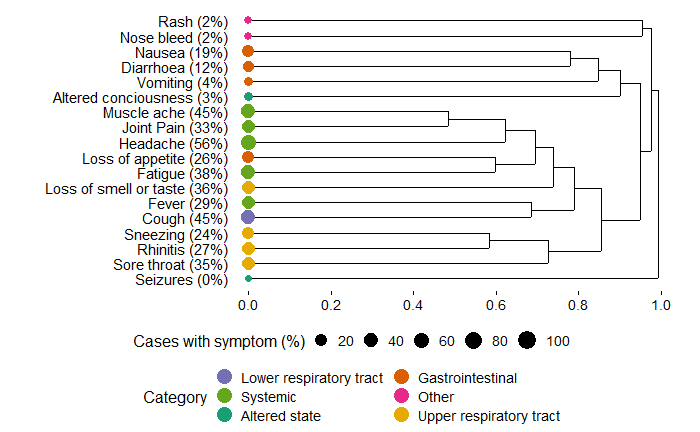

```r
CTAS_sgss_dendrogram
```

### Heatmap

```r
# get the ordering from the dendrogram
CTAS_sgss_order = order.dendrogram(CTAS_sgss_dendro_dd_row)

# Order the levels according to their position in the dendrogram
CTAS_sgss_long$symptom_name_formatted.x = factor(
  x = CTAS_sgss_long$symptom_name_formatted.x,
  levels = CTAS_sgss_long$symptom_name_formatted.x[CTAS_sgss_order],
  ordered = TRUE
)
CTAS_sgss_long$symptom_name_formatted.y = factor(
  x = CTAS_sgss_long$symptom_name_formatted.y,
  levels = CTAS_sgss_long$symptom_name_formatted.x[rev(CTAS_sgss_order)],
  ordered = TRUE
)
```

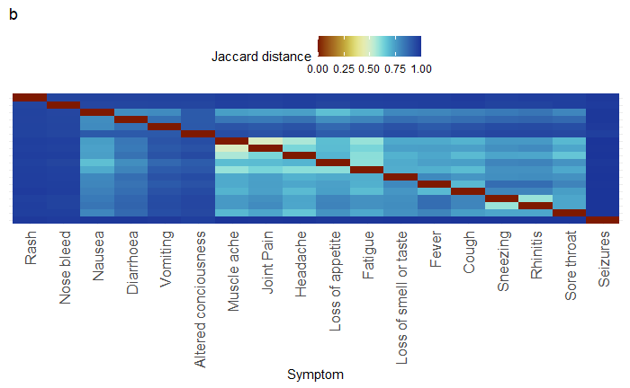

```r
CTAS_SGSS_heatmap <- ggplot(
  data = CTAS_sgss_long,
  aes(
    x = symptom_name_formatted.y,
    y = symptom_name_formatted.x
    )
  ) +
  geom_tile(aes(fill = value)) +
  theme_minimal() +
  z_axis_scale +
  heatmap_theme +
  xlab("Symptom") +
  labs(
    title = 'b',
    fill = "Jaccard distance")
CTAS_SGSS_heatmap
```

```r
CTAS_SGSS_DendroHeatmap = ggdraw() +
  draw_plot(CTAS_SGSS_heatmap, x = 0, y = 0, width = .45, height = 1) +
  draw_plot(CTAS_sgss_dendrogram, x = 0.42, y = 0.06, width = 0.56, height = 0.81)

# ggsave(
#   'Figures/HeirarchalClustering/CTAS_SGSS_DendroHeatmap.png',
#   plot = CTAS_SGSS_DendroHeatmap, width = 12)
```

## ONS - all

```r
ONS_dendro_dd_row = as.dendrogram(
  hclust(
    ONS_dist,
    method = 'complete'
    )
  )
ONS_dendro_data = dendro_data(ONS_dendro_dd_row)
```

```r
ONS_dendro_data$labels = ONS_dendro_data$labels %>%
  left_join(ONS_symptom_names_df,
            by = c('label' = 'symptom_name_raw'))
```

```r
ONS_dendrogram <- ggplot(segment(ONS_dendro_data)) +
  geom_segment(
    aes(x=x, y=y, xend=xend, yend=yend)) +
  geom_text(
    data=label(ONS_dendro_data),
    aes(
      label=symptom_name_formatted_with_perc,
      x=x,
      y=-0.05,
      angle='0',
      hjust = 1,
      label_size = text_size)) +
  geom_point(
    data = ONS_dendro_data$labels,
    aes(
      x=x,
      y=0,
      size=proportion_fromsymptomatics,
      color=category)) +
  labs(
    size = 'Cases with symptom (%)',
    color = 'Category'
    ) +
  theme_cowplot(font_size = 12) +
  remove_axis_arrange_legend +
  shifted_y_scale +
  colour_scale_all +
  size_scaling +
  coord_flip() +
  category_legend
```

```
Ignoring unknown aesthetics: label_size
```

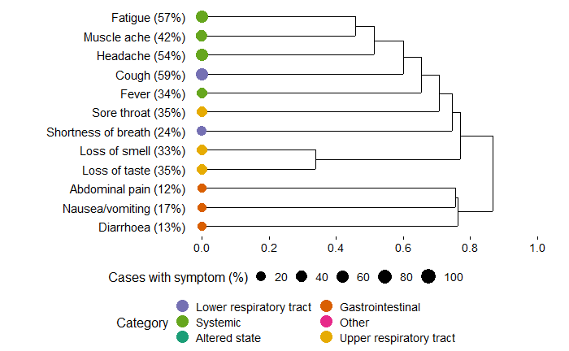

```r
ONS_dendrogram
```

### Heatmap

```r
# get the ordering from the dendrogram
ONS_order = order.dendrogram(ONS_dendro_dd_row)

# Order the levels according to their position in the dendrogram
ONS_long$symptom_name_formatted.x = factor(
  x = ONS_long$symptom_name_formatted.x,
  levels = ONS_long$symptom_name_formatted.x[ONS_order],
  ordered = TRUE
)
ONS_long$symptom_name_formatted.y = factor(
  x = ONS_long$symptom_name_formatted.y,
  levels = ONS_long$symptom_name_formatted.x[rev(ONS_order)],
  ordered = TRUE
)
```

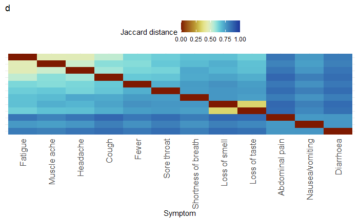

```r
ONS_heatmap <- ggplot(
  data = ONS_long,
  aes(
    x = symptom_name_formatted.y,
    y = symptom_name_formatted.x
    )
  ) +
  geom_tile(aes(fill = value)) +
  theme_minimal() +
  z_axis_scale +
  heatmap_theme +
  xlab("Symptom") +
  labs(
    title = 'd',
    fill = "Jaccard distance")
ONS_heatmap
```

### Arranging

```r
ONS_DendroHeatmap = ggdraw() +
  draw_plot(ONS_heatmap, x = 0, y = 0, width = .45, height = 1) +
  draw_plot(ONS_dendrogram, x = 0.42, y = 0.05, width = 0.55, height = 0.81)

# ggsave(
#   'Figures/HeirarchalClustering/ONS_DendroHeatmap.png',
#   plot = ONS_DendroHeatmap, width = 12)
```

## ONS - children

```r
ONS_children_dendro_dd_row = as.dendrogram(
  hclust(
    ONS_dist_children,
    method = 'complete'
    )
  )
ONS_children_dendro_data = dendro_data(ONS_children_dendro_dd_row)
```

```r
ONS_children_dendro_data$labels = ONS_children_dendro_data$labels %>%
  left_join(ONS_symptom_names_df_children,
            by = c('label' = 'symptom_name_raw'))
```

```r
ONS_children_dendrogram <- ggplot(segment(ONS_children_dendro_data)) +
  geom_segment(
    aes(x=x, y=y, xend=xend, yend=yend)) +
  geom_text(
    data=label(ONS_children_dendro_data),
    aes(
      label=symptom_name_formatted_with_perc,
      x=x,
      y=-0.05,
      angle='0',
      hjust = 1,
      label_size = text_size)) +
  geom_point(
    data = ONS_children_dendro_data$labels,
    aes(
      x=x,
      y=0,
      size=proportion_fromsymptomatics,
      color=category)) +
  labs(
    size = 'Cases with symptom (%)',
    color = 'Category'
    ) +
  theme_cowplot(font_size = 12) +
  remove_axis_arrange_legend +
  shifted_y_scale +
  colour_scale_all +
  size_scaling +
  coord_flip() +
  category_legend
```

```
Ignoring unknown aesthetics: label_size
```

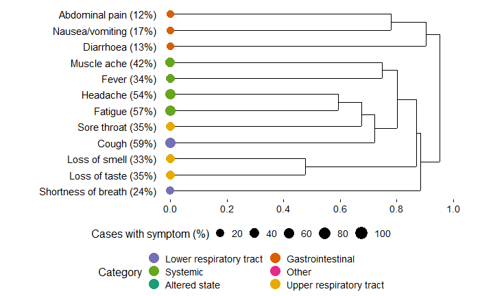

```r
ONS_children_dendrogram
```

### Heatmap

```r
# get the ordering from the dendrogram
ONS_order = order.dendrogram(ONS_children_dendro_dd_row)

# Order the levels according to their position in the dendrogram
ONS_children_long$symptom_name_formatted.x = factor(
  x = ONS_children_long$symptom_name_formatted.x,
  levels = ONS_children_long$symptom_name_formatted.x[ONS_order],
  ordered = TRUE
)
ONS_children_long$symptom_name_formatted.y = factor(
  x = ONS_children_long$symptom_name_formatted.y,
  levels = ONS_children_long$symptom_name_formatted.x[rev(ONS_order)],
  ordered = TRUE
)
```

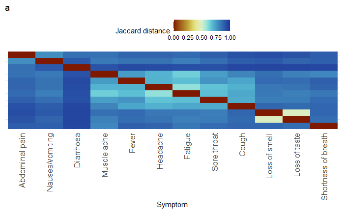

```r
ONS_children_heatmap <- ggplot(
  data = ONS_children_long,
  aes(
    x = symptom_name_formatted.y,
    y = symptom_name_formatted.x
    )
  ) +
  geom_tile(aes(fill = value)) +
  theme_minimal() +
  z_axis_scale +
  heatmap_theme +
  xlab("Symptom") +
  labs(
    title= 'a',
    fill = "Jaccard distance")
ONS_children_heatmap
```

### Arranging

```r
ONS_children_DendroHeatmap = ggdraw() +
  draw_plot(ONS_children_heatmap, x = 0, y = 0, width = .45, height = 1) +
  draw_plot(ONS_children_dendrogram, x = 0.42, y = 0.05, width = 0.56, height = 0.81)

# ggsave(
#   'Figures/HeirarchalClustering/ONS_children_DendroHeatmap.png',
#   plot = ONS_children_DendroHeatmap, width = 12)
```

## ONS - adults

```r
ONS_adults_dendro_dd_row = as.dendrogram(
  hclust(
    ONS_dist_adults,
    method = 'complete'
    )
  )
ONS_adults_dendro_data = dendro_data(ONS_adults_dendro_dd_row)
```

```r
ONS_adults_dendro_data$labels = ONS_adults_dendro_data$labels %>%
  left_join(ONS_symptom_names_df_adults,
            by = c('label' = 'symptom_name_raw'))
```

```r
ONS_adults_dendrogram <- ggplot(segment(ONS_adults_dendro_data)) +
  geom_segment(
    aes(x=x, y=y, xend=xend, yend=yend)) +
  geom_text(
    data=label(ONS_adults_dendro_data),
    aes(
      label=symptom_name_formatted_with_perc,
      x=x,
      y=-0.05,
      angle='0',
      hjust = 1,
      label_size = text_size)) +
  geom_point(
    data = ONS_adults_dendro_data$labels,
    aes(
      x=x,
      y=0,
      size=proportion_fromsymptomatics,
      color=category)) +
  labs(
    size = 'Cases with symptom (%)',
    color = 'Category'
    ) +
  theme_cowplot(font_size = 12) +
  remove_axis_arrange_legend +
  shifted_y_scale +
  colour_scale_all +
  size_scaling +
  coord_flip() +
  category_legend
```

```
Ignoring unknown aesthetics: label_size
```

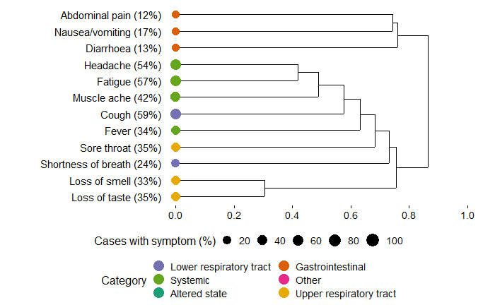

```r
ONS_adults_dendrogram
```

### Heatmap

```r
# get the ordering from the dendrogram
ONS_order = order.dendrogram(ONS_adults_dendro_dd_row)

# Order the levels according to their position in the dendrogram
ONS_adults_long$symptom_name_formatted.x = factor(
  x = ONS_adults_long$symptom_name_formatted.x,
  levels = ONS_adults_long$symptom_name_formatted.x[ONS_order],
  ordered = TRUE
)
ONS_adults_long$symptom_name_formatted.y = factor(
  x = ONS_adults_long$symptom_name_formatted.y,
  levels = ONS_adults_long$symptom_name_formatted.x[rev(ONS_order)],
  ordered = TRUE
)
```

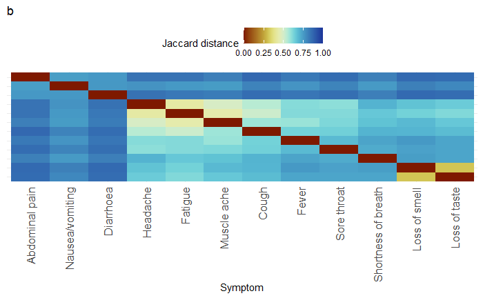

```r
ONS_adults_heatmap <- ggplot(
  data = ONS_adults_long,
  aes(
    x = symptom_name_formatted.y,
    y = symptom_name_formatted.x
    )
  ) +
  geom_tile(aes(fill = value)) +
  theme_minimal() +
  z_axis_scale +
  heatmap_theme +
  xlab("Symptom") +
  labs(
    title = 'b',
    fill = "Jaccard distance")
ONS_adults_heatmap
```

### Arranging

```r
ONS_adults_DendroHeatmap = ggdraw() +
  draw_plot(ONS_adults_heatmap, x = 0, y = 0, width = .45, height = 1) +
  draw_plot(ONS_adults_dendrogram, x = 0.42, y = 0.05, width = 0.56, height = 0.81)

# ggsave(
#   'Figures/HeirarchalClustering/ONS_adults_DendroHeatmap.png',
#   plot = ONS_adults_DendroHeatmap, width = 12)
```

## ONS - elders

```r
ONS_elder_dendro_dd_row = as.dendrogram(
  hclust(
    ONS_dist_elder,
    method = 'complete'
    )
  )
ONS_elder_dendro_data = dendro_data(ONS_elder_dendro_dd_row)
```

```r
ONS_elder_dendro_data$labels = ONS_elder_dendro_data$labels %>%
  left_join(ONS_symptom_names_df_elder,
            by = c('label' = 'symptom_name_raw'))
```

```r
ONS_elder_dendrogram <- ggplot(segment(ONS_elder_dendro_data)) +
  geom_segment(
    aes(x=x, y=y, xend=xend, yend=yend)) +
  geom_text(
    data=label(ONS_elder_dendro_data),
    aes(
      label=symptom_name_formatted_with_perc,
      x=x,
      y=-0.05,
      angle='0',
      hjust = 1,
      label_size = text_size)) +
  geom_point(
    data = ONS_elder_dendro_data$labels,
    aes(
      x=x,
      y=0,
      size=proportion_fromsymptomatics,
      color=category)) +
  labs(
    size = 'Cases with symptom (%)',
    color = 'Category'
    ) +
  theme_cowplot(font_size = 12) +
  remove_axis_arrange_legend +
  shifted_y_scale +
  colour_scale_all +
  size_scaling +
  coord_flip() +
  category_legend
```

```
Ignoring unknown aesthetics: label_size
```

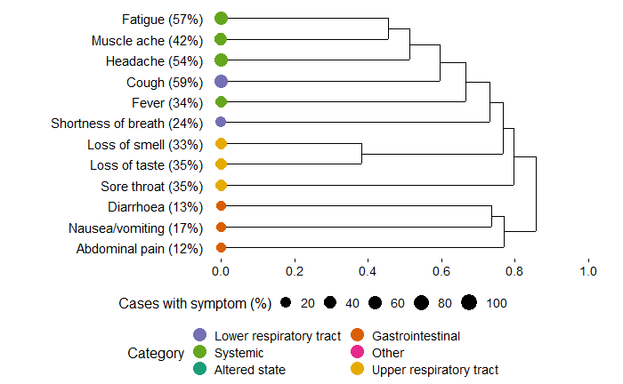

```r
ONS_elder_dendrogram
```

### Heatmap

```r
# get the ordering from the dendrogram
ONS_order = order.dendrogram(ONS_elder_dendro_dd_row)

# Order the levels according to their position in the dendrogram
ONS_elder_long$symptom_name_formatted.x = factor(
  x = ONS_elder_long$symptom_name_formatted.x,
  levels = ONS_elder_long$symptom_name_formatted.x[ONS_order],
  ordered = TRUE
)
ONS_elder_long$symptom_name_formatted.y = factor(
  x = ONS_elder_long$symptom_name_formatted.y,
  levels = ONS_elder_long$symptom_name_formatted.x[rev(ONS_order)],
  ordered = TRUE
)
```

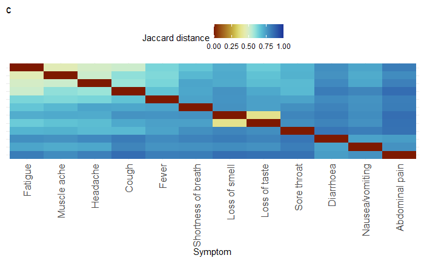

```r
ONS_elder_heatmap <- ggplot(
  data = ONS_elder_long,
  aes(
    x = symptom_name_formatted.y,
    y = symptom_name_formatted.x
    )
  ) +
  geom_tile(aes(fill = value)) +
  theme_minimal() +
  z_axis_scale +
  heatmap_theme +
  xlab("Symptom") +
  labs(
    title = 'c',
    fill = "Jaccard distance")
ONS_elder_heatmap
```

### Arranging

```r
ONS_elder_DendroHeatmap = ggdraw() +
  draw_plot(ONS_elder_heatmap, x = 0, y = 0, width = .45, height = 1) +
  draw_plot(ONS_elder_dendrogram, x = 0.42, y = 0.05, width = 0.56, height = 0.81)

# ggsave(
#   'Figures/HeirarchalClustering/ONS_elder_DendroHeatmap.png',
#   plot = ONS_elder_DendroHeatmap, width = 12)
```

## Zoe all

```r
CSS_dendro_dd_row = as.dendrogram(
  hclust(
    CSS_dist,
    method = 'complete'
    )
  )
CSS_dendro_data = dendro_data(CSS_dendro_dd_row)
```

```r
CSS_dendro_data$labels = CSS_dendro_data$labels %>%
  left_join(CSS_symptom_names_df, by = c('label' = 'symptom_name_raw'))
```

```r
CSS_dendrogram <- ggplot(segment(CSS_dendro_data)) +
  geom_segment(
    aes(x=x, y=y, xend=xend, yend=yend)) +
  geom_text(
    data=label(CSS_dendro_data),
    aes(
      label=symptom_name_formatted_with_perc,
      x=x,
      y=-0.05,
      angle='0',
      hjust = 1,
      label_size = text_size)) +
  geom_point(
    data = CSS_dendro_data$labels,
    aes(
      x=x,
      y=0,
      size=proportion*100,
      color=category
    )) +
  labs(
    size = 'Cases with symptom (%)',
    color = 'Category'
    ) +
  theme_cowplot(font_size = 12) +
  remove_axis_arrange_legend +
  shifted_y_scale +
  colour_scale_all +
  coord_flip() +
  category_legend +
  size_scaling
```

```
Ignoring unknown aesthetics: label_size
```

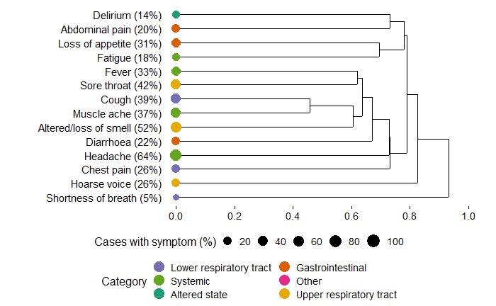

```r
CSS_dendrogram
```

### Heatmap

```r
# get the ordering from the dendrogram
CSS_order = order.dendrogram(CSS_dendro_dd_row)

# Order the levels according to their position in the dendrogram
CSS_long$symptom_name_formatted.x = factor(
  x = CSS_long$symptom_name_formatted.x,
  levels = CSS_long$symptom_name_formatted.x[CSS_order],
  ordered = TRUE
)
CSS_long$symptom_name_formatted.y = factor(
  x = CSS_long$symptom_name_formatted.y,
  levels = CSS_long$symptom_name_formatted.x[rev(CSS_order)],
  ordered = TRUE
)
```

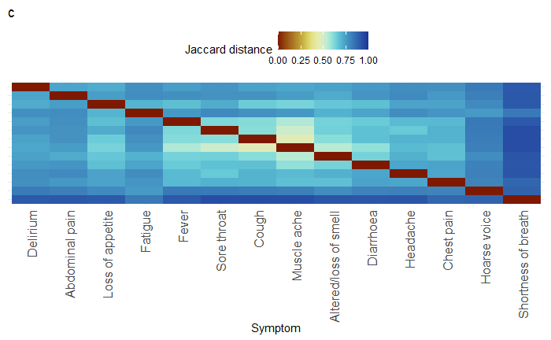

```r
CSS_heatmap <- ggplot(
  data = CSS_long,
  aes(
    x = symptom_name_formatted.y,
    y = symptom_name_formatted.x
    )
  ) +
  geom_tile(aes(fill = value)) +
  theme_minimal() +
  z_axis_scale +
  heatmap_theme +
  xlab("Symptom") +
  labs(
    title = 'c',
    fill = "Jaccard distance")
CSS_heatmap
```

### Arranging

```r
CSS_DendroHeatmap = ggdraw() +
  draw_plot(CSS_heatmap, x = 0, y = 0, width = .45, height = 1) +
  draw_plot(CSS_dendrogram, x = 0.435, y = 0.0525, width = 0.56, height = 0.815)

# ggsave(
#   'Figures/HeirarchalClustering/Zoe_DendroHeatmap.png',
#   plot = CSS_DendroHeatmap, width = 12)
```

## Zoe children

```r
zoe_dendro_dd_row = as.dendrogram(
  hclust(
    zoe_dist_children,
    method = 'complete'
    )
  )
zoe_dendro_data = dendro_data(zoe_dendro_dd_row)
```

```r
zoe_dendro_data$labels = zoe_dendro_data$labels %>%
  left_join(zoe_symptom_names_df_children, by = c('label' = 'symptom_name_raw'))
```

```r
zoe_dendrogram_children <- ggplot(segment(zoe_dendro_data)) +
  geom_segment(
    aes(x=x, y=y, xend=xend, yend=yend)) +
  geom_text(
    data=label(zoe_dendro_data),
    aes(
      label=symptom_name_formatted_with_perc,
      x=x,
      y=-0.05,
      angle='0',
      hjust = 1,
      label_size = text_size)) +
  geom_point(
    data = zoe_dendro_data$labels,
    aes(
      x=x,
      y=0,
      size=proportion*100,
      color=category
    )) +
  labs(
    size = 'Cases with symptom (%)',
    color = 'Category'
    ) +
  theme_cowplot(font_size = 12) +
  remove_axis_arrange_legend +
  shifted_y_scale +
  colour_scale_all +
  coord_flip() +
  category_legend +
  size_scaling
```

```
Ignoring unknown aesthetics: label_size
```

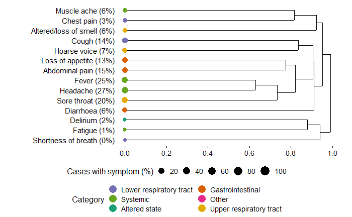

```r
zoe_dendrogram_children
```

### Heatmap

```r
# get the ordering from the dendrogram
zoe_order = order.dendrogram(zoe_dendro_dd_row)

# Order the levels according to their position in the dendrogram
Zoe_long_children$symptom_name_formatted.x = factor(
  x = Zoe_long_children$symptom_name_formatted.x,
  levels = Zoe_long_children$symptom_name_formatted.x[zoe_order],
  ordered = TRUE
)
Zoe_long_children$symptom_name_formatted.y = factor(
  x = Zoe_long_children$symptom_name_formatted.y,
  levels = Zoe_long_children$symptom_name_formatted.x[rev(zoe_order)],
  ordered = TRUE
)
```

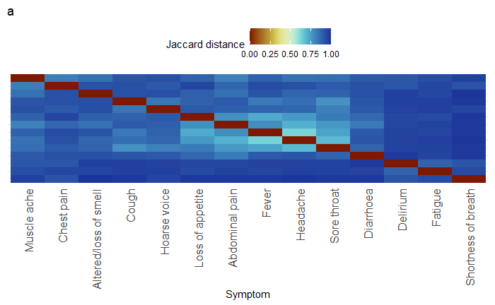

```r
Zoe_heatmap_children <- ggplot(
  data = Zoe_long_children,
  aes(
    x = symptom_name_formatted.y,
    y = symptom_name_formatted.x
    )
  ) +
  geom_tile(aes(fill = value)) +
  theme_minimal() +
  z_axis_scale +
  heatmap_theme +
  xlab("Symptom") +
  labs(
    title = 'a',
    fill = "Jaccard distance")
Zoe_heatmap_children
```

### Arranging

```r
Zoe_DendroHeatmap_children = ggdraw() +
  draw_plot(Zoe_heatmap_children, x = 0, y = 0, width = .45, height = 1) +
  draw_plot(zoe_dendrogram_children, x = 0.435, y = 0.0525, width = 0.56, height = 0.815)

# ggsave(
#   'Figures/HeirarchalClustering/Zoe_DendroHeatmap_children.png',
#   plot = Zoe_DendroHeatmap_children, width = 12)
```

## Zoe adults

```r
zoe_dendro_dd_row = as.dendrogram(
  hclust(
    zoe_dist_adults,
    method = 'complete'
    )
  )
zoe_dendro_data = dendro_data(zoe_dendro_dd_row)
```

```r
zoe_dendro_data$labels = zoe_dendro_data$labels %>%
  left_join(zoe_symptom_names_df_adults, by = c('label' = 'symptom_name_raw'))
```

```r
zoe_dendrogram_adults <- ggplot(segment(zoe_dendro_data)) +
  geom_segment(
    aes(x=x, y=y, xend=xend, yend=yend)) +
  geom_text(
    data=label(zoe_dendro_data),
    aes(
      label=symptom_name_formatted_with_perc,
      x=x,
      y=-0.05,
      angle='0',
      hjust = 1,
      label_size = text_size)) +
  geom_point(
    data = zoe_dendro_data$labels,
    aes(
      x=x,
      y=0,
      size=proportion*100,
      color=category
    )) +
  labs(
    size = 'Cases with symptom (%)',
    color = 'Category'
    ) +
  theme_cowplot(font_size = 12) +
  remove_axis_arrange_legend +
  shifted_y_scale +
  colour_scale_all +
  coord_flip() +
  category_legend +
  size_scaling
```

```
Ignoring unknown aesthetics: label_size
```

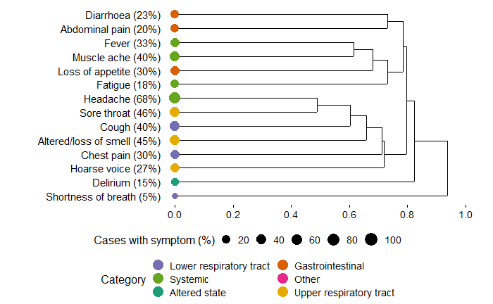

```r
zoe_dendrogram_adults
```

### Heatmap

```r
# get the ordering from the dendrogram
zoe_order = order.dendrogram(zoe_dendro_dd_row)

# Order the levels according to their position in the dendrogram
Zoe_long_adults$symptom_name_formatted.x = factor(
  x = Zoe_long_adults$symptom_name_formatted.x,
  levels = Zoe_long_adults$symptom_name_formatted.x[zoe_order],
  ordered = TRUE
)
Zoe_long_adults$symptom_name_formatted.y = factor(
  x = Zoe_long_adults$symptom_name_formatted.y,
  levels = Zoe_long_adults$symptom_name_formatted.x[rev(zoe_order)],
  ordered = TRUE
)
```

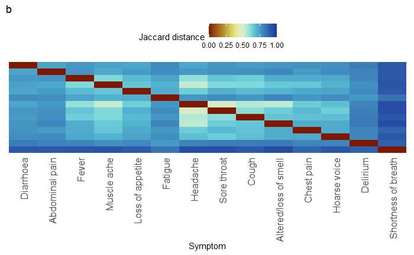

```r
Zoe_heatmap_adults <- ggplot(
  data = Zoe_long_adults,
  aes(
    x = symptom_name_formatted.y,
    y = symptom_name_formatted.x
    )
  ) +
  geom_tile(aes(fill = value)) +
  theme_minimal() +
  z_axis_scale +
  heatmap_theme +
  xlab("Symptom") +
  labs(
    title = 'b',
    fill = "Jaccard distance")
Zoe_heatmap_adults
```

### Arranging

```r
Zoe_DendroHeatmap_adults = ggdraw() +
  draw_plot(Zoe_heatmap_adults, x = 0, y = 0, width = .45, height = 1) +
  draw_plot(zoe_dendrogram_adults, x = 0.435, y = 0.0525, width = 0.56, height = 0.815)

# ggsave(
#   'Figures/HeirarchalClustering/Zoe_DendroHeatmap_adults.png',
#   plot = Zoe_DendroHeatmap_adults, width = 12)
```

## Zoe elders

```r
zoe_dendro_dd_row = as.dendrogram(
  hclust(
    zoe_dist_elder,
    method = 'complete'
    )
  )
zoe_dendro_data = dendro_data(zoe_dendro_dd_row)
```

```r
zoe_dendro_data$labels = zoe_dendro_data$labels %>%
  left_join(zoe_symptom_names_df_elder, by = c('label' = 'symptom_name_raw'))
```

```r
zoe_dendrogram_elder <- ggplot(segment(zoe_dendro_data)) +
  geom_segment(
    aes(x=x, y=y, xend=xend, yend=yend)) +
  geom_text(
    data=label(zoe_dendro_data),
    aes(
      label=symptom_name_formatted_with_perc,
      x=x,
      y=-0.05,
      angle='0',
      hjust = 1,
      label_size = text_size)) +
  geom_point(
    data = zoe_dendro_data$labels,
    aes(
      x=x,
      y=0,
      size=proportion*100,
      color=category
    )) +
  labs(
    size = 'Cases with symptom (%)',
    color = 'Category'
    ) +
  theme_cowplot(font_size = 12) +
  remove_axis_arrange_legend +
  shifted_y_scale +
  colour_scale_all +
  coord_flip() +
  category_legend +
  size_scaling
```

```
Ignoring unknown aesthetics: label_size
```

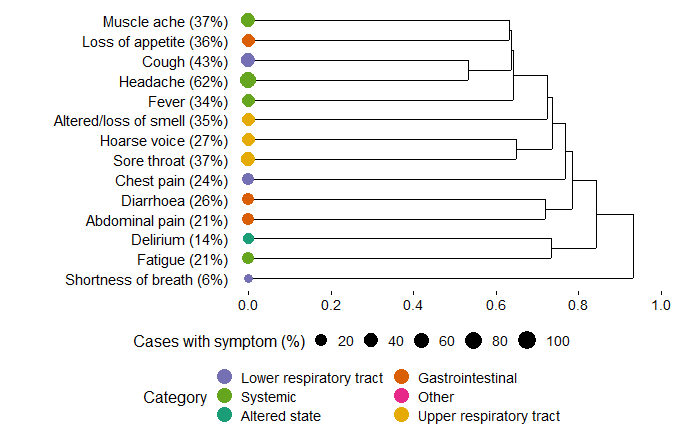

```r
zoe_dendrogram_elder
```

### Heatmap

```r
# get the ordering from the dendrogram
zoe_order = order.dendrogram(zoe_dendro_dd_row)

# Order the levels according to their position in the dendrogram
Zoe_long_elder$symptom_name_formatted.x = factor(
  x = Zoe_long_elder$symptom_name_formatted.x,
  levels = Zoe_long_elder$symptom_name_formatted.x[zoe_order],
  ordered = TRUE
)
Zoe_long_elder$symptom_name_formatted.y = factor(
  x = Zoe_long_elder$symptom_name_formatted.y,
  levels = Zoe_long_elder$symptom_name_formatted.x[rev(zoe_order)],
  ordered = TRUE
)
```

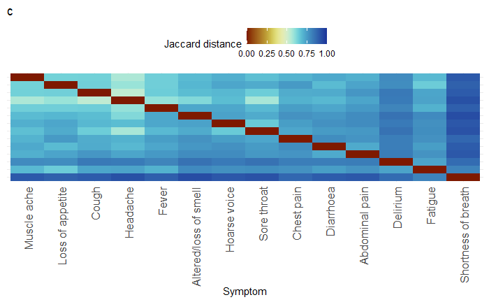

```r
Zoe_heatmap_elder <- ggplot(
  data = Zoe_long_elder,
  aes(
    x = symptom_name_formatted.y,
    y = symptom_name_formatted.x
    )
  ) +
  geom_tile(aes(fill = value)) +
  theme_minimal() +
  z_axis_scale +
  heatmap_theme +
  xlab("Symptom") +
  labs(
    title = 'c',
    fill = "Jaccard distance")
Zoe_heatmap_elder
```

### Arranging

```r
Zoe_DendroHeatmap_elder = ggdraw() +
  draw_plot(Zoe_heatmap_elder, x = 0, y = 0, width = .45, height = 1) +
  draw_plot(zoe_dendrogram_elder, x = 0.435, y = 0.0525, width = 0.56, height = 0.815)

# ggsave(
#   'Figures/HeirarchalClustering/Zoe_DendroHeatmap_elder.png',
#   plot = Zoe_DendroHeatmap_elder, width = 12)
```

## CTAS Pillar 2 - children

```r
p2_children_dendro_dd_row = as.dendrogram(
  hclust(
    p2_dist_children,
    method = 'complete'
    )
  )
p2_children_dendro_data = dendro_data(p2_children_dendro_dd_row)
```

```r
p2_children_dendro_data$labels = p2_children_dendro_data$labels %>%
  left_join(
    p2_symptom_names_df_children,
    by = c('label' = 'symptom_name_raw')
    )
```

```r
p2_children_dendrogram <- ggplot(segment(p2_children_dendro_data)) +
  geom_segment(
    aes(x=x, y=y, xend=xend, yend=yend)) +
  geom_text(
    data=label(p2_children_dendro_data),
    aes(
      label=symptom_name_formatted_with_perc,
      x=x,
      y=-0.05,
      angle='0',
      hjust = 1,
      label_size = text_size)) +
  geom_point(
    data = p2_children_dendro_data$labels,
    aes(
      x=x,
      y=0,
      size=proportion_of_cases_with_symptom*100,
      color=category)) +
  labs(
    size = 'Cases with symptom (%)',
    color = 'Category') +
  theme_cowplot(font_size = 12) +
  remove_axis_arrange_legend +
  shifted_y_scale +
  colour_scale_all +
  size_scaling +
  coord_flip() +
  category_legend
```

```
Ignoring unknown aesthetics: label_size
```

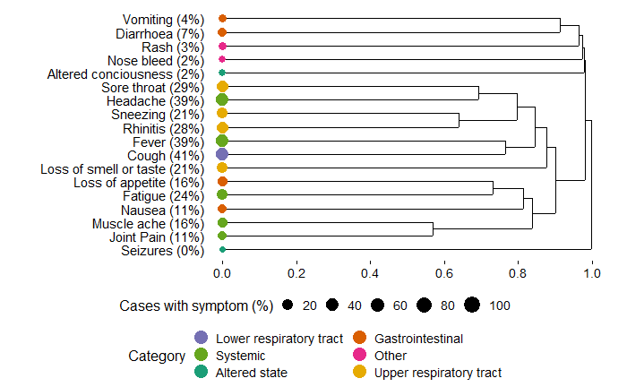

```r
p2_children_dendrogram
```

### Heatmap

```r
# get the ordering from the dendrogram
p2_children_order = order.dendrogram(p2_children_dendro_dd_row)

# Order the levels according to their position in the dendrogram
CTAS_p2_children_long$symptom_name_formatted.x = factor(
  x = CTAS_p2_children_long$symptom_name_formatted.x,
  levels = CTAS_p2_children_long$symptom_name_formatted.x[p2_children_order],
  ordered = TRUE
)

CTAS_p2_children_long$symptom_name_formatted.y = factor(
  x = CTAS_p2_children_long$symptom_name_formatted.y,
  levels = CTAS_p2_children_long$symptom_name_formatted.x[rev(p2_children_order)],
  ordered = TRUE
)
```

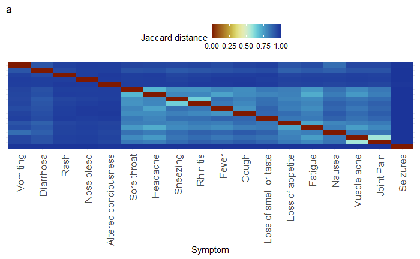

```r
p2_children_heatmap <- ggplot(
  data = CTAS_p2_children_long,
  aes(
    x = symptom_name_formatted.y,
    y = symptom_name_formatted.x
    )
  ) +
  geom_tile(aes(fill = value)) +
  theme_minimal() +
  z_axis_scale +
  heatmap_theme +
  xlab("Symptom") +
  labs(
    title = 'a',
    fill = "Jaccard distance")
p2_children_heatmap
```

### Arranging

```r
p2_children_DendroHeatmap = ggdraw() +
  draw_plot(p2_children_heatmap, x = 0, y = 0, width = .45, height = 1) +
  draw_plot(p2_children_dendrogram, x = 0.42, y = 0.06, width = 0.56, height = 0.81)

# ggsave(
#   'Figures/HeirarchalClustering/p2_children_DendroHeatmap.png',
#   plot = p2_children_DendroHeatmap, width = 12)
```

## CTAS Pillar 2 - adults

```r
p2_adults_dendro_dd_row = as.dendrogram(
  hclust(
    p2_dist_adults,
    method = 'complete'
    )
  )
p2_adults_dendro_data = dendro_data(p2_adults_dendro_dd_row)
```

```r
p2_adults_dendro_data$labels = p2_adults_dendro_data$labels %>%
  left_join(
    p2_symptom_names_df_adults,
    by = c('label' = 'symptom_name_raw')
    )
```

```r
p2_adults_dendrogram <- ggplot(segment(p2_adults_dendro_data)) +
  geom_segment(
    aes(x=x, y=y, xend=xend, yend=yend)) +
  geom_text(
    data=label(p2_adults_dendro_data),
    aes(
      label=symptom_name_formatted_with_perc,
      x=x,
      y=-0.05,
      angle='0',
      hjust = 1,
      label_size = text_size)) +
  geom_point(
    data = p2_adults_dendro_data$labels,
    aes(
      x=x,
      y=0,
      size=proportion_of_cases_with_symptom*100,
      color=category)) +
  labs(
    size = 'Cases with symptom (%)',
    color = 'Category') +
  theme_cowplot(font_size = 12) +
  remove_axis_arrange_legend +
  shifted_y_scale +
  colour_scale_all +
  size_scaling +
  coord_flip() +
  category_legend
```

```
Ignoring unknown aesthetics: label_size
```

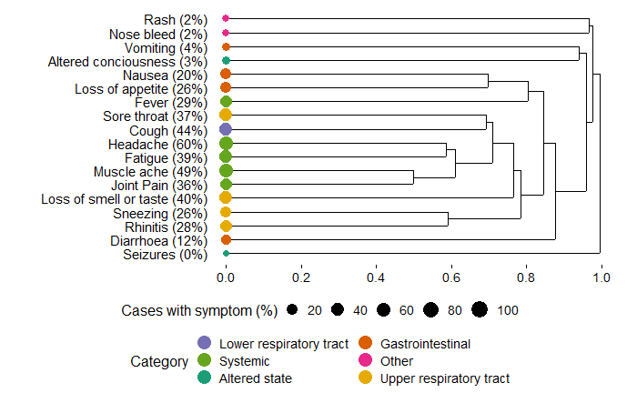

```r
p2_adults_dendrogram
```

### Heatmap

```r
# get the ordering from the dendrogram
p2_adults_order = order.dendrogram(p2_adults_dendro_dd_row)

# Order the levels according to their position in the dendrogram
CTAS_p2_adults_long$symptom_name_formatted.x = factor(
  x = CTAS_p2_adults_long$symptom_name_formatted.x,
  levels = CTAS_p2_adults_long$symptom_name_formatted.x[p2_adults_order],
  ordered = TRUE
)

CTAS_p2_adults_long$symptom_name_formatted.y = factor(
  x = CTAS_p2_adults_long$symptom_name_formatted.y,
  levels = CTAS_p2_adults_long$symptom_name_formatted.x[rev(p2_adults_order)],
  ordered = TRUE
)
```

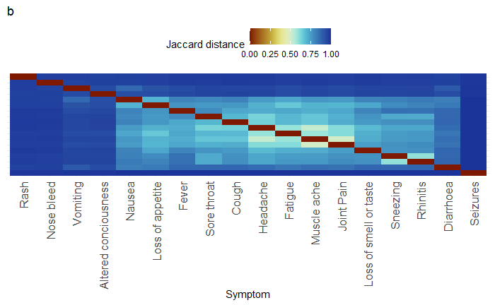

```r
p2_adults_heatmap <- ggplot(
  data = CTAS_p2_adults_long,
  aes(
    x = symptom_name_formatted.y,
    y = symptom_name_formatted.x
    )
  ) +
  geom_tile(aes(fill = value)) +
  theme_minimal() +
  z_axis_scale +
  heatmap_theme +
  xlab("Symptom") +
  labs(
    title = 'b',
    fill = "Jaccard distance")
p2_adults_heatmap
```

### Arranging

```r
p2_adults_DendroHeatmap = ggdraw() +
  draw_plot(p2_adults_heatmap, x = 0, y = 0, width = .45, height = 1) +
  draw_plot(p2_adults_dendrogram, x = 0.42, y = 0.06, width = 0.56, height = 0.81)

# ggsave(
#   'Figures/HeirarchalClustering/p2_adults_DendroHeatmap.png',
#   plot = p2_adults_DendroHeatmap, width = 12)
```